# Guide to Understanding the CTT Web Portal

support@celltracktech.com

11/2/2021

# 1 Navigating the new ES-420 User Interface (UI) Website

Welcome to the new CTT Web Portal. Currently this portal is dedicated to display of data from the new Evolution Series 420 (ES-420) GPS/GSM transmitters. As this portal is currently in beta, it is very likely that you will be seeing changes happening rapidly over the coming months. Eventually this portal will provide access to all of your transmitters, and allow a unified user interface for everything from our radio products through GPS/GSM and including Satellite (Iridium and Argos). Until then, non-ES-420 devices are still only accessible from https://accounts.celltracktech.com. We apologize for any inconvenience that this may cause, but we are confident that your user experience will be better than ever once we complete the migration to our new server architecture. As always, if you have any questions please don’t hesitate to reach out to us via support@celltracktech.com. Happy tracking!

## 1.1 Logging in

Well, if you are reading this from the portal, you’ve already figured it out! Of course, if you haven’t yet logged in, you should have received your login credentials in the shipping email sent when your units left our building. This attachment also includes your device IDs. For accessing your ES-420 devices please use the following URL: https://beta.internetofwildlife.com/

## 1.2 Main Page: My CTT

On the new main page, titled `My CTT`, you’ll see several windows, including the current weather at your location (you will need to allow **Location Services** for this to display), and a `Support` window for accessing documentation and other CTT portals including the `Legacy Site`, or https://accounts.celltracktech.com.

[figure not shown]

**My CTT** *dashboard*

## 1.3 Charts Tab

*This section is still under construction and new data will be added imminently. Please check the online version for the most up-to-date user guide.*

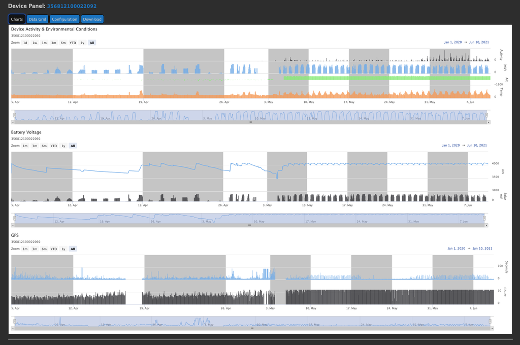

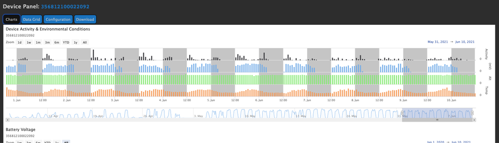

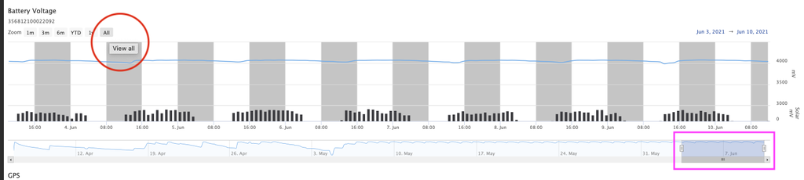

## 1.4 Data Grid Tab

*This section is still under construction and new data will be added imminently. Please check the online version for the most up-to-date user guide.*

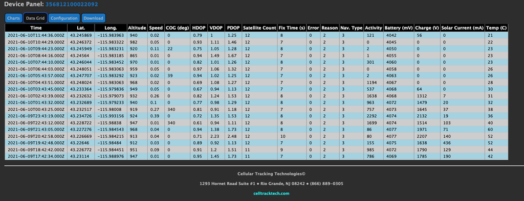

## 1.5 Configuration Tab

From the configuration tab you can see both the current configuration loaded on your unit, and the assignment history.

## 1.6 Current Assignment Sub-tab

This panel shows the **latest configuration** running on the unit **since the last check-in**. **This is important, because newly assigned configs will not update until the check-in following the one where the unit took the config.**

*This section is still under construction and new data will be added imminently. Please check the online version for the most up-to-date user guide.*

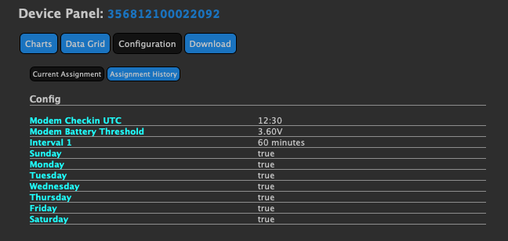

## 1.7 Assignment History Sub-tab

This section is under construction and new data will be added imminently. Please check the online version for the most up-to-date user guide.

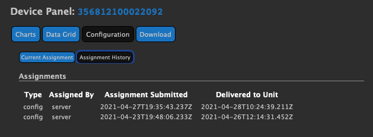

## 1.8 Download Tab

*This section is still under construction and new data will be added imminently. Please check the online version for the most up-to-date user guide.*

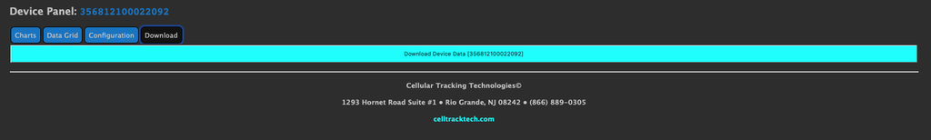

# 2 Further Support